# Dynamic ODE model

Author

Haylee Oyler, Jo Cardelle

Consider the following model of forest growth (where forest size in measured ni units of carbon (C))

The size of the forest (C), Canopy closure threshold and carrying capacity are al ni units of carbon You could think of the canopy closure threshold as the size of the forest at which growth rates change from exponential to linear You can think of r, as early exponential growth rate and gas the linear growth rate once canopy closure has been reached

```r
library(tidyverse)
library(deSolve)
library(sensitivity)
library(here)

source(here("hw5/dforestgrowth.R"))
source(here("hw5/maxforest.R"))
source(here("hw5/maxforestwrapper.R"))
```

### Forest Growth Model

```r
# Initial population
Cinitial <- c(C=10)

# Time period over 300 years
simtimes <- seq(from = 1, to = 300)

# List of parameters
parms <- list(r = 0.01,
              g = 2,
              K = 250,
              thresh = 50)

# Run the ODE model
result <- ode(y = Cinitial, times = simtimes, func = dforestgrowth, parms = parms)
```

## Graphing the Forest Growth Model

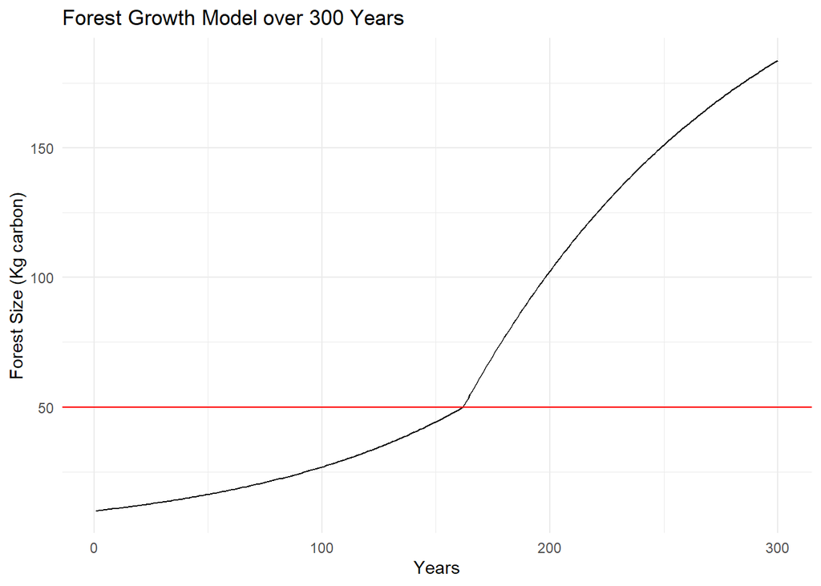

```r
# Graph forest growth over time
ggplot(result, aes(time, C)) +
  geom_line() +
  geom_hline(yintercept = 50, col = "red") +
  labs(y = "Forest Size (Kg carbon)",
       title = "Forest Growth Model over 300 Years",
       x = "Years") +
  theme_minimal()
```

## Sobol Sensitivity Analysis

```r
# Set initial population
Cinitial <- 10

# Create parameter distributions
np <- 2000
K <- rnorm(mean = 250, sd = 25, n = np)
r <- rnorm(mean = 0.01, sd = 0.001, n = np)
g <- rnorm(mean = 0.2, sd = 0.02, n = np)
X1 <- cbind.data.frame(r = r, K = K, g = g)
# We don't vary thresh so add it here statically
X1 <- X1 %>%
  mutate(thresh = 50)

# Repeat for second set of samples
np <- 2000
K <- rnorm(mean = 250, sd = 25, n = np)
r <- rnorm(mean = 0.01, sd = 0.001, n = np)
g <- rnorm(mean = 0.2, sd = 0.02, n = np)
X2 <- cbind.data.frame(r = r, K = K, g = g)
# We don't vary thresh so add it here statically
X2 <- X2 %>%
  mutate(thresh = 50)

# Fix any negative values and they are not meaningful
X1 <- X1 %>% map_df(pmax, 0.0)
X2 <- X2 %>% map_df(pmax, 0.0)

# Run the sobol analysis
sens_C <- sobolSalt(model = NULL, X1, X2, nboot = 300)

# Add parameter names
colnames(sens_C$X) <- c("r", "K", "g", "thresh")
head(sens_C$X)
```

```
               r        K         g thresh
[1,] 0.007722154 235.1232 0.1939309     50
[2,] 0.010911011 223.0035 0.1934885     50
[3,] 0.011546765 213.2768 0.1939884     50
[4,] 0.011396033 242.1938 0.2355321     50
[5,] 0.008584014 182.9653 0.2132126     50
[6,] 0.009555955 292.8063 0.2149409     50
```